# Topographic Change caused by People

Matthew Ross updated by Karin Emanuelson

9/23/2019

# Analyzing topographic change in the USA

## USGS analysis of topographic change

Analysis background can be found here: https://www.usgs.gov/land-resources/eros/topochange

### Download the data

```r
#Create a new folder
dir.create('data')

#Download files
download.file(url='https://edcintl.cr.usgs.gov/downloads/sciweb1/shared/topo/downloads/Topochange/topo_change_polygons_Shapefile.zip',destfile='data/topo_change.zip')

# List files in the data directory
#list.files('data')

#Unzip the dataset
unzip('data/topo_change.zip',exdir='data/topo_change')

#Check that the unzipping worked
#list.files('data/topo_change')
```

### Check out the data

```r
topo_change <- st_read('data/topo_change/topo_change_polygons.shp')
```

```r
#Checkout the column names
#names(topo_change)

biggest_area <- topo_change %>%
  arrange(desc(AREA_SQ_KM)) %>%
  slice(1:10)

# Map all mines
mapview(biggest_area)
```

[interactive chart not shown]

### Checkout mine in Arizona

```r
# Subset to just Arizona
az_mine <- biggest_area %>%
  filter(QUADNAME == 'esperanza_mill_AZ')

#Check that it is the right site
mapview(az_mine)
```

[interactive chart not shown]

## Getting our own elevation datasets

### Download pre-mining DEM

```r
#Check projection of az_mine
#st_crs(az_mine)

az_raster_before <- get_elev_raster(az_mine,z=12)
```

```
## Merging DEMs
```

```
## Reprojecting DEM to original projection
```

```
## Note: Elevation units are in meters.
## Note: The coordinate reference system is:
##  +proj=aea +lat_1=29.5 +lat_2=45.5 +lat_0=23 +lon_0=-96 +x_0=0 +y_0=0 +datum=NAD83 +units=m +no_defs +ellps=GRS80 +towgs84=0,0,0
```

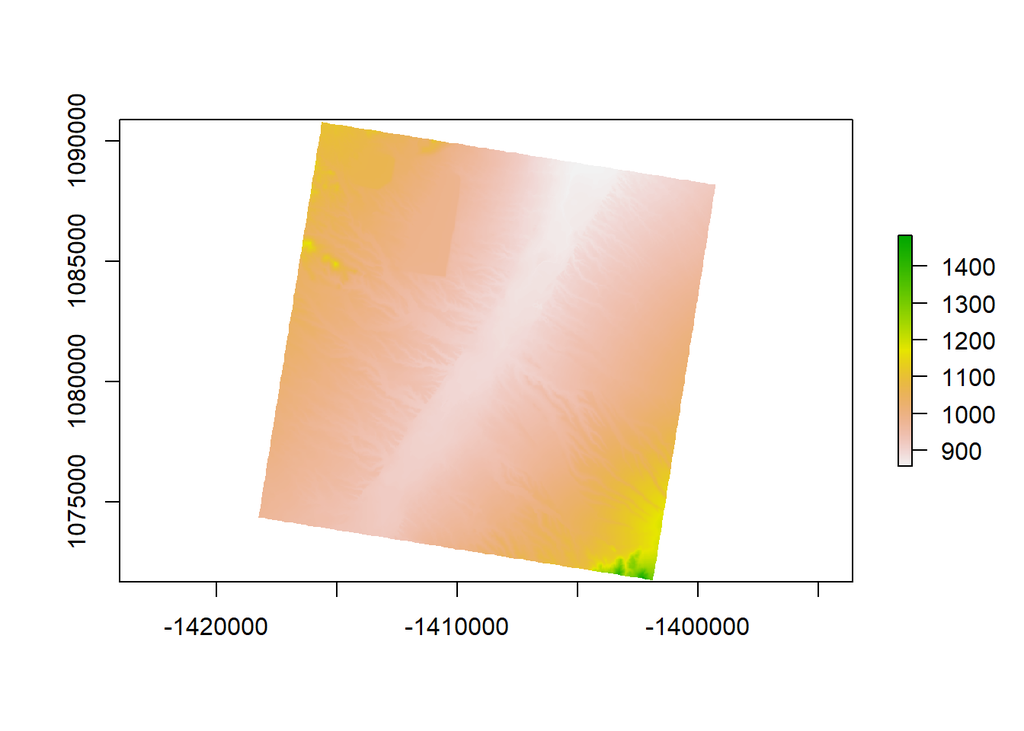

```r
#Look at the structure of the data
#str(az_raster)

#Summary of the data
#summary(az_raster)

plot(az_raster_before)
```

### Download post-mining DEM

Data comes from [SRTM](https://www2.jpl.nasa.gov/srtm/)

```r
#Extract centroid of mine polygon
az_center <- st_centroid(az_mine) %>%
  st_transform(4326)
#Map it to check
mapview(az_center)

#Get coords
coords <- st_coordinates(az_center)


getData('SRTM',lon=coords[1],lat=coords[2],
        path='data')
```

### Read in SRTM data

```r
az_raster_after <- raster('data/srtm_14_06.tif')
```

## Looking at Elevation change before and after mining

### Clip SRTM data to NED data

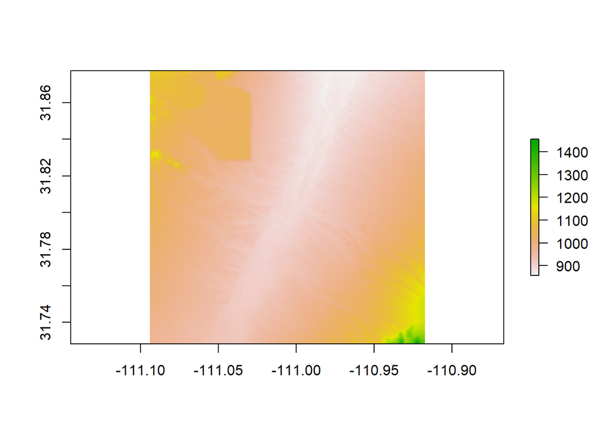

```r
#Check resolution of rasters
# res(az_raster_after)
# res(az_raster_before)

#Check the projection
# projection(az_raster_after)
# projection(az_raster_before)


#Reproject small raster to larger raster projection
az_raster_before_reproj <- projectRaster(az_raster_before,
                                        az_raster_after)

#Trim whitespace
az_raster_before_trim <- trim(az_raster_before_reproj)

#Crop to match extents
az_raster_after_clip <- crop(az_raster_after,az_raster_before_trim)

#Plot clipped dataset
plot(az_raster_after_clip)
```

### Taking the difference and plotting it

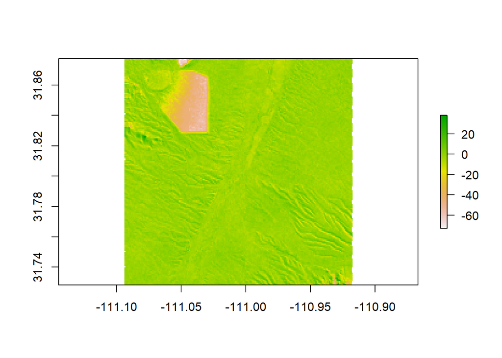

```r
# Take the elevation difference
dem_diff <- az_raster_before_trim - az_raster_after_clip

plot(dem_diff)
```

# In-class work

## 1) What is the maximum/minimum elevation change caused by mining?

You may want to check out the command maxValue and minValue

```r
# maximum elevation change
maxValue(dem_diff)
```

```
## [1] 38.48263
```

```r
# minimum elevation change
minValue(dem_diff)
```

```
## [1] -73
```

The greatest elevation change caused by mining was a decrease of 73 meters

## 2) What is the background elevation “error” between NED and SRTM?

The national elevation dataset (NED) and the Shuttle Radar Topography Mission are extremely different ways to estimate elevation. NED is derived from thousands of compiled elevation datasets that can be collected on the ground, from LiDAR or other ways, while SRTM is collected with radar from space. As a result, we naturally expect there to be some background differences in these two DEMs, so what is the average difference in these DEMs in parts of the landscape that have not undergone substantial elevation change?

### 2a) Buffer the az_mine object by 5 kilometers using the sf::st_buffer command

```r
az_min_buff<-sf::st_buffer(az_mine, 5000)
```

### 2b) Use the the st_transform command to transform the

projection of your buffered az_mine dataset to the same projection as the dem_diff raster dataset

hint: you may want to explore st_crs to help you here

```r
# Check projection of demdiff
st_crs(dem_diff)
```

```
## Coordinate Reference System:
##   EPSG: 4326
##   proj4string: "+proj=longlat +datum=WGS84 +no_defs"
```

```r
#transform projection of buffered az_mine using code determined above
az_mine_buff_trans<-st_transform(az_min_buff, crs = 4326)
```

### 2c) Use the raster::mask command to mask out all the

areas inside of the buffered and reprojected az_mine dataset.

hint: look at the mask command and try to understand what the inverse option does

```r
#look at only the dem diff outside of the mine area
dem_diff_masked<-mask(dem_diff, az_mine_buff_trans, inverse = TRUE)

# check to make sure it worked
# mapview(dem_diff_masked)
```

### 2d) Use the summary command to look at the summary of

differences between these two DEMs in areas where there has been no mining

```r
summary(dem_diff_masked)
```

```
##                 layer
## Min.      -51.7853626
## 1st Qu.    -3.0000000
## Median     -1.1290558
## 3rd Qu.     0.5889633
## Max.       33.2005297
## NA's    14680.0000000
```

## 3) What does the shape of the “error” distribution look like

in areas that have not been mined versus areas that have been mined?

To look at distributional changes, we may want to convert this raster dataset back into a data.frame or tibble type shape so that we can take advantage of ggplots plotting capabilities and make a plot of the two dems.

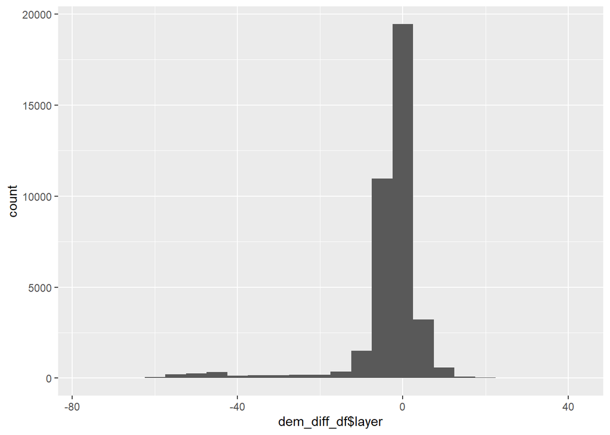

```r
# make into dataframe
dem_diff_masked_df<-as.data.frame(dem_diff_masked)
dem_diff_df<-as.data.frame(dem_diff)

# Graph (DEM- SRTM) areas that have been mined
ggplot(dem_diff_df, aes(dem_diff_df$layer))+
  geom_histogram(binwidth = 5)
```

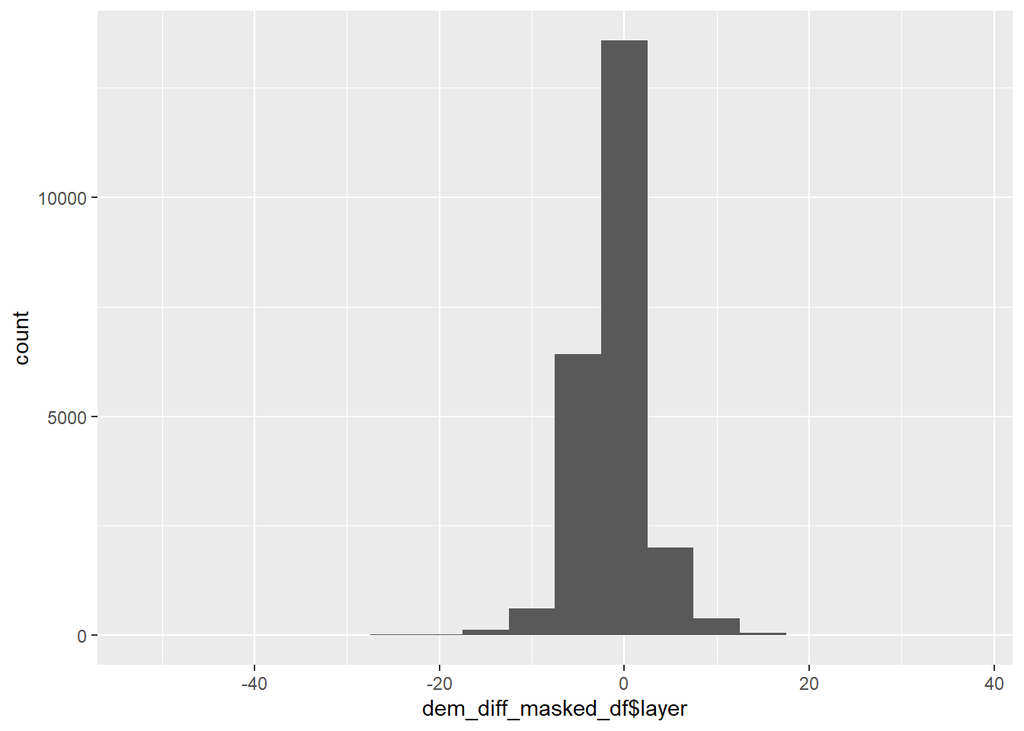

```r
# majority of the diferences are centered around 0 then some greater differences are seen to have a -40 meter difference.

# Graph areas that have not been mined
ggplot(dem_diff_masked_df, aes(dem_diff_masked_df$layer))+
  geom_histogram(binwidth = 5)
```

```r
# Tells that the SRTM is overestimating by error in the dem difference centered around 0

# Comparing the two graphs I would only trust a dem diff greater than -20 m anything less than that could be due to error.
```

### 3a) Mask the raster dem_diff dataset to the exact outlines of the

USGS az_mine dataset

```r
# Check projection of demdiff
st_crs(dem_diff)
```

```
## Coordinate Reference System:
##   EPSG: 4326
##   proj4string: "+proj=longlat +datum=WGS84 +no_defs"
```

```r
#transform projection of buffered az_mine using code determined above
az_mine_trans<-st_transform(az_mine, crs = 4326)

#look at only the dem diff outside of the mine area
dem_diff_masked_az<-mask(dem_diff, az_mine_trans, inverse = FALSE)

#Make Dataframe
dem_diff_masked_az_df<-as.data.frame(dem_diff_masked_az)

# #View to check
# mapview(dem_diff_masked_az)
```

### 3b) Use the getValues command to extract the elevation

values from both the unmined and mined regions of your rasters. Label these vectors as `unmined_dem` and `mined_dem`.

```r
#Values for the unmined regions
unmined_dem<-getValues(dem_diff_masked)

#Values for the mined regions
mined_dem<-getValues(dem_diff_masked_az)
```

### 3c) Use ggplot and the command geom_density() to look at

the differences in mined and unmined regions of Arizona.

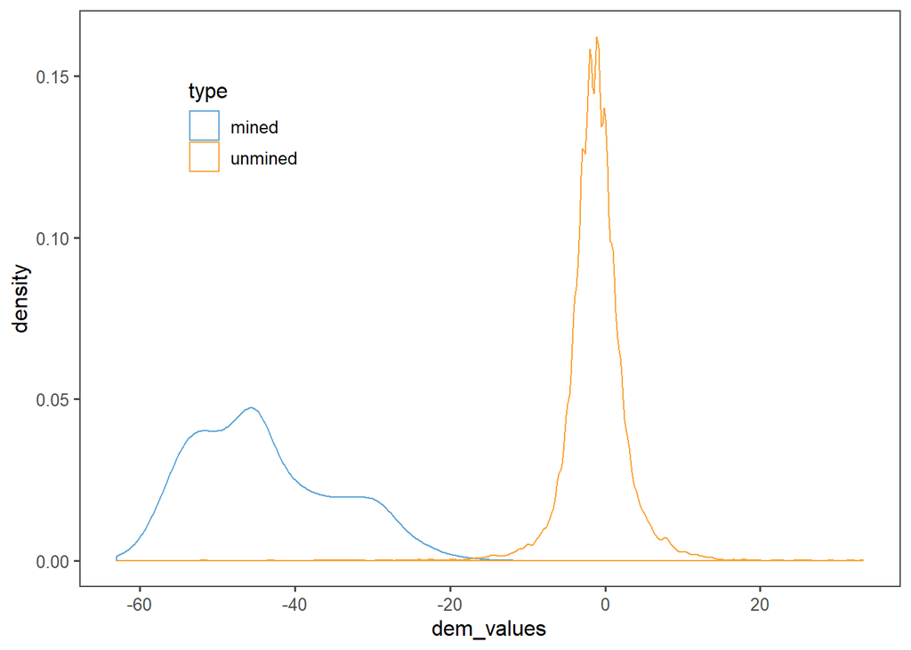

```r
# Here I'm just making the table for you

unmined_type <- rep('unmined',length(unmined_dem))
mined_type <- rep('mined',length(mined_dem))
mined_table <- tibble(dem_values = c(unmined_dem,mined_dem),
                      type = c(unmined_type,mined_type))

ggplot(data=mined_table, aes(x=dem_values, color=type))+
  geom_density()+
  theme_few() +
  scale_color_few() +
  theme(legend.position=c(0.2,0.8))
```